# Prob 5, CP 2: Regress??o Log??stica e match

Thierry Barros

August 5, 2018

```r
library(GGally)
library(pscl)
library(broom)
library(tidyverse)
library(modelr) # devtools::install_github("hadley/modelr")
theme_set(theme_bw())
```

Leitura dos dados rom??nticos, com `dec`, que diz se p1 gostaria de se encontrar novamente com p2:

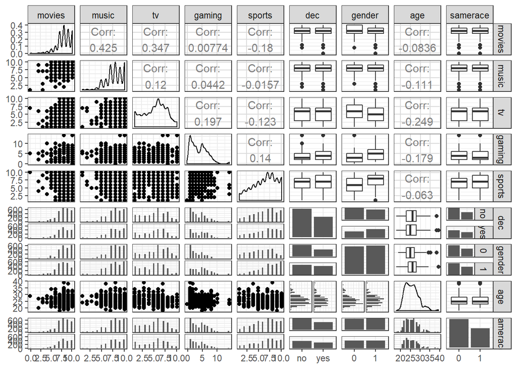

```r
dados = read.csv("speed-dating/speed-dating2.csv")

dados <- dados %>%
  select(movies, music, tv, gaming, sports, dec,gender,age,samerace) %>%
  na.omit() %>%
  mutate(
         gender = as.character(gender),
         samerace = as.character(samerace))

ggpairs(dados)
```

Como podemos ver as correla????es acima parece ter efeitos, positivos e negativos, entre as vari??veis analisadas e a vari??vel dec.

Analisando a rela????o entre a dec e o samerace, n??o parece ter muita rela????o entre as vari??veis. A propor????o de dec(no,yes) de acordo com o a vari??vel samerace n??o parece alterar muito. S?? que tem mais dados de pessoas com ra??a diferente(Isso ?? bom para mostrar que o preconceito racial est?? diminuindo, vai Planeta!).

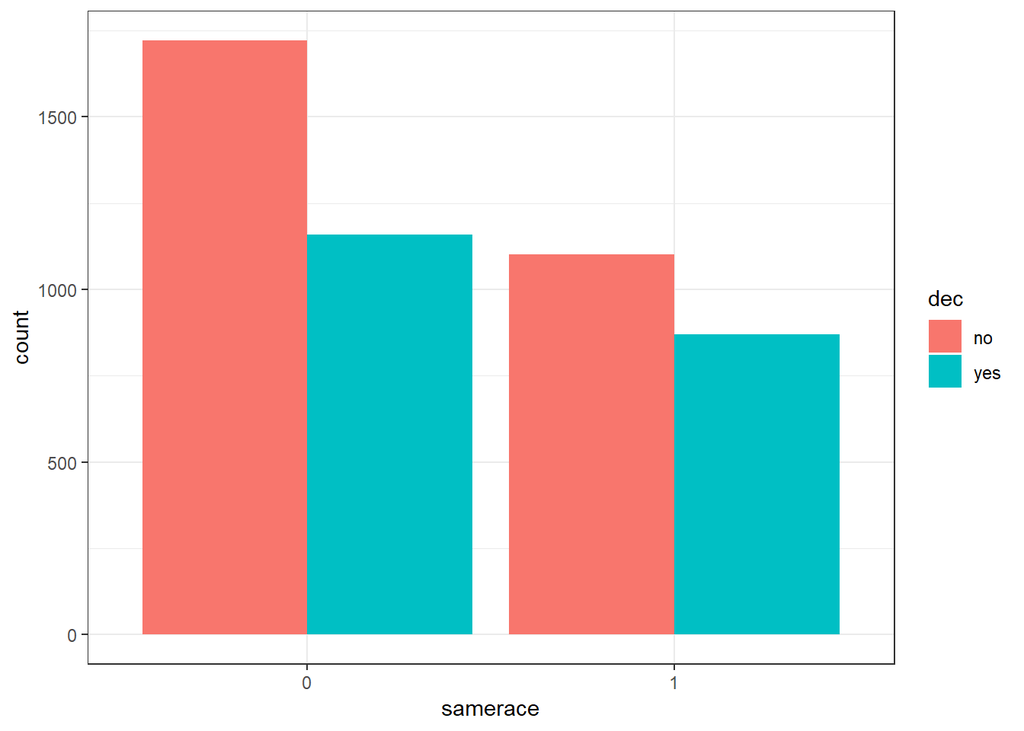

```r
dados %>%
  ggplot(aes(x = samerace, fill = dec)) +
  geom_bar(position = "dodge")
```

Outra maneira de avaliar rela????o entre uma vari??vel gaming(gostos por jogos eletr??nicos) e a dec(reencontro). Como podemos ver quanto mais a pessoa gosta de gaming mais chance tem de ter uma dec(reecontro).

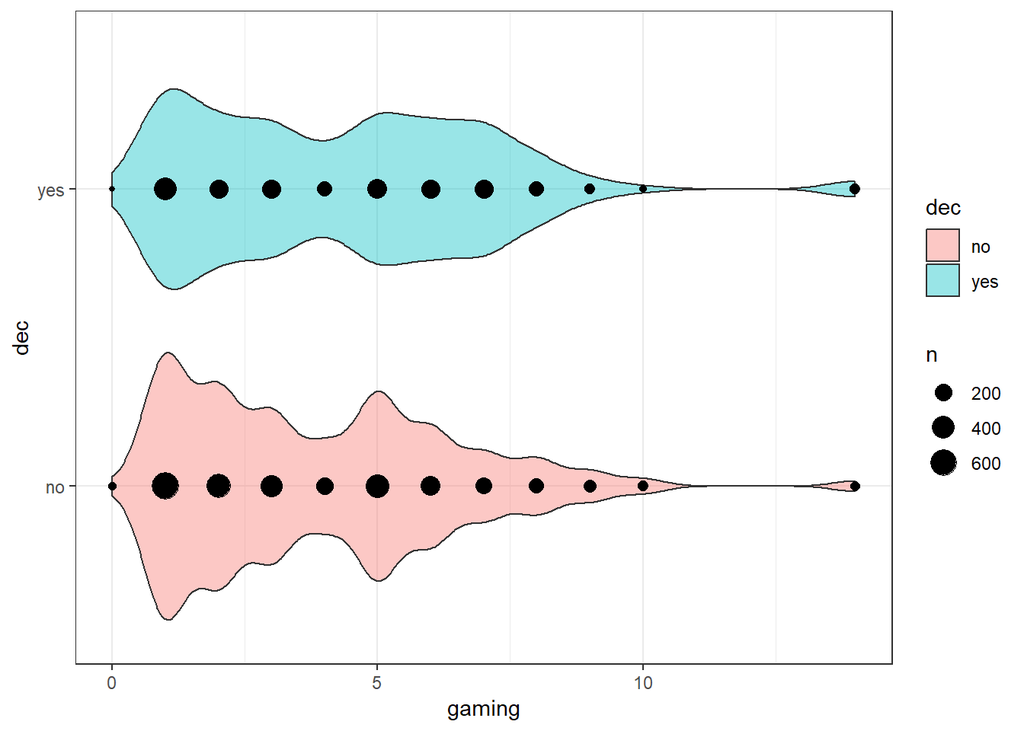

```r
dados %>%
  ggplot(aes(x = dec, y = gaming)) +
  geom_violin(aes(fill = dec), alpha = .4) +
  #geom_boxplot(aes(fill = survived), alpha = .4) +
  geom_count() +
  #geom_jitter(width = .1, alpha = .3) +
  coord_flip()
```

# Fit univariado

Analisando os dados usando odds ratio:

```r
bm <- glm(dec ~ gaming,
          data = dados,
          family = "binomial")

tidy(bm, conf.int = TRUE) %>%
  select(-statistic, -p.value)
```

```
##          term    estimate  std.error    conf.low  conf.high
## 1 (Intercept) -0.58680414 0.05352427 -0.69202911 -0.4821867
## 2      gaming  0.06293503 0.01093789  0.04152912  0.0844158
```

```r
tidy(bm, conf.int = TRUE, exponentiate = TRUE) %>%
  select(-statistic, -p.value)
```

```
##          term  estimate  std.error  conf.low conf.high
## 1 (Intercept) 0.5561017 0.05352427 0.5005593 0.6174317
## 2      gaming 1.0649576 0.01093789 1.0424035 1.0880812
```

Parece ter uma reala????o pequena, mas positiva, entre o dec e ratio. devido ao peso de gaming na fun????o 1.0649576.

```r
teste = data.frame(gaming = 1:5)

bm %>%
  augment(newdata = teste,
          type.predict = "response")
```

```
##   gaming   .fitted     .se.fit
## 1      1 0.3719480 0.010455797
## 2      2 0.3867643 0.008814412
## 3      3 0.4017932 0.007593881
## 4      4 0.4170090 0.007106791
## 5      5 0.4323845 0.007565203
```

N??o tem R2 nesse tipo de modelo, oque dificulta a analise de qualidade do modelo criado.

```r
glance(bm)
```

```
##   null.deviance df.null    logLik      AIC      BIC deviance df.residual
## 1      6592.954    4849 -3279.827 6563.654 6576.628 6559.654        4848
```

```r
pR2(bm)
```

```
##           llh       llhNull            G2      McFadden          r2ML
## -3.279827e+03 -3.296477e+03  3.329940e+01  5.050756e-03  6.842339e-03
##          r2CU
##  9.206865e-03
```

## Visualizando o modelo

O modelo praticamente ficou ajustados aos dados em uma fun????o linear:

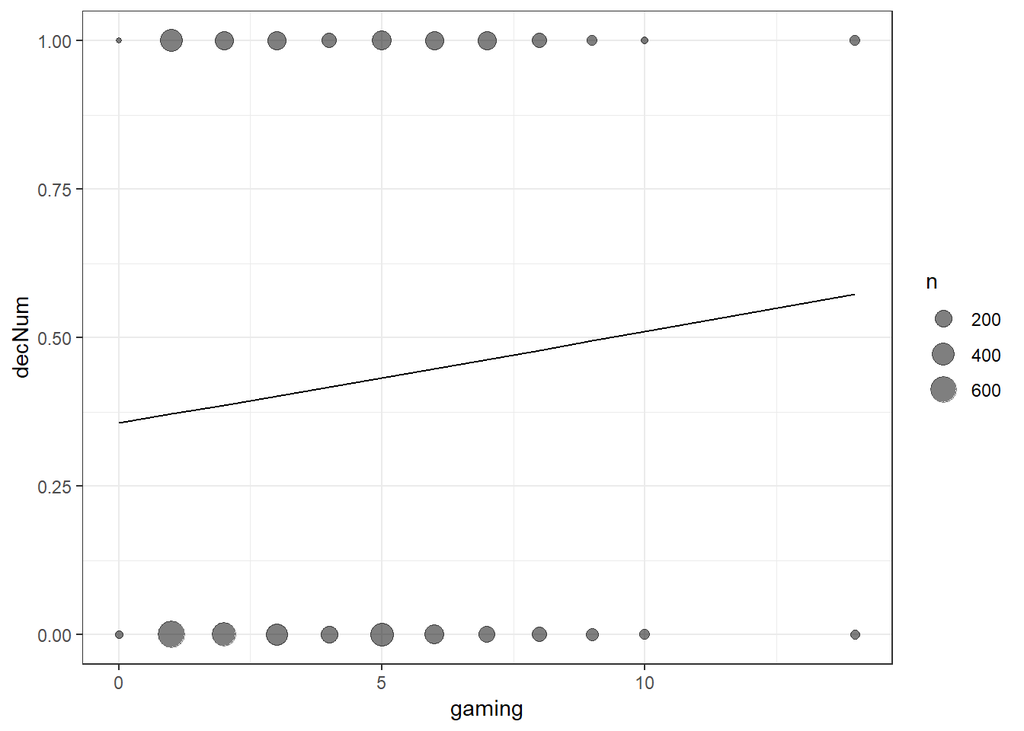

```r
bm %>%
  augment(type.predict = "response")  %>%
  mutate(decNum = ifelse(dec == "yes", 1, 0)) %>%
  ggplot(aes(x = gaming)) +
  geom_count(aes(y = decNum), alpha = 0.5) +
  geom_line(aes(y = .fitted))
```

## Preditor cat??gorico

Agora fazendo um modelo para calcular a rela????o entre dados categ??ricos gender e dec.

```r
bm <- glm(dec ~ gender,
          data = dados,
          family = "binomial")
tidy(bm, conf.int = TRUE)
```

```
##          term   estimate  std.error  statistic      p.value   conf.low
## 1 (Intercept) -0.5367315 0.04233907 -12.676977 7.933247e-37 -0.6200281
## 2     gender1  0.4012352 0.05856690   6.850887 7.339322e-12  0.2865611
##    conf.high
## 1 -0.4540375
## 2  0.5161565
```

```r
glance(bm)
```

```
##   null.deviance df.null    logLik      AIC      BIC deviance df.residual
## 1      6592.954    4849 -3272.875 6549.751 6562.724 6545.751        4848
```

```r
pR2(bm)
```

```
##           llh       llhNull            G2      McFadden          r2ML
## -3.272875e+03 -3.296477e+03  4.720325e+01  7.159651e-03  9.685420e-03
##          r2CU
##  1.303244e-02
```

```r
#summary(bm)
```

Como podemos ver no gr??fico abaixo parece que h?? sim uma varia????o de dec, de acordo com o gender. Parece que quando o gender ?? 1(Acho que ?? mulher), tem mais chances de o dec(reecontro) ser positivo.

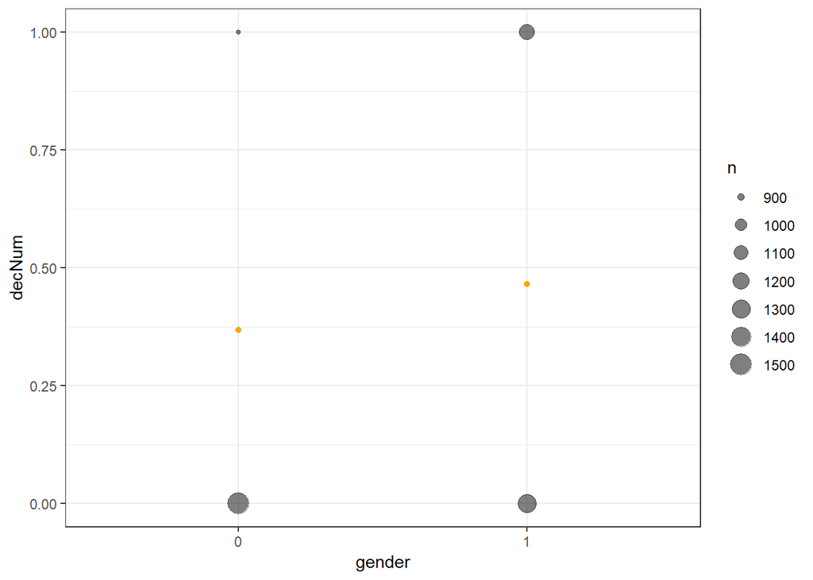

```r
bm %>%
  augment(type.predict = "response")  %>%
  mutate(decNum = ifelse(dec == "yes", 1, 0)) %>%
  ggplot(aes(x = gender)) +
  geom_count(aes(y = decNum), alpha = 0.5) +
  geom_point(aes(y = .fitted), color = "orange")
```

# Multivariada

```r
bm <- glm(dec ~  gender + samerace + age,
          data = dados,
          family = "binomial")

tidy(bm, conf.int = TRUE)
```

```
##          term   estimate   std.error  statistic      p.value    conf.low
## 1 (Intercept) -0.1491116 0.228664295 -0.6520984 5.143377e-01 -0.59689398
## 2     gender1  0.4120492 0.058854091  7.0011988 2.537814e-12  0.29682271
## 3   samerace1  0.1645693 0.059527489  2.7645938 5.699372e-03  0.04787714
## 4         age -0.0178724 0.008799811 -2.0309977 4.225523e-02 -0.03516457
##      conf.high
## 1  0.299654391
## 2  0.527544546
## 3  0.281240307
## 4 -0.000661321
```

```r
tidy(bm, conf.int = TRUE, exponentiate = TRUE)
```

```
##          term  estimate   std.error  statistic      p.value  conf.low
## 1 (Intercept) 0.8614730 0.228664295 -0.6520984 5.143377e-01 0.5505189
## 2     gender1 1.5099087 0.058854091  7.0011988 2.537814e-12 1.3455767
## 3   samerace1 1.1788853 0.059527489  2.7645938 5.699372e-03 1.0490418
## 4         age 0.9822864 0.008799811 -2.0309977 4.225523e-02 0.9654465
##   conf.high
## 1 1.3493924
## 2 1.6947658
## 3 1.3247719
## 4 0.9993389
```

```r
glance(bm)
```

```
##   null.deviance df.null    logLik      AIC     BIC deviance df.residual
## 1      6592.954    4849 -3267.132 6542.263 6568.21 6534.263        4846
```

```r
pR2(bm)
```

```
##           llh       llhNull            G2      McFadden          r2ML
## -3.267132e+03 -3.296477e+03  5.869053e+01  8.902009e-03  1.202822e-02
##          r2CU
##  1.618484e-02
```

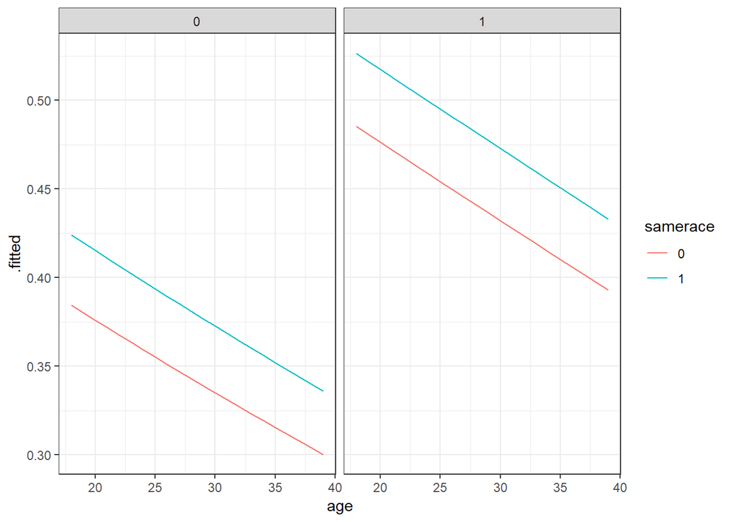

```r
m = dados %>%
  data_grid(gender, samerace, age)
mm = augment(bm,
             newdata = m,
             type.predict = "response")

ggplot(mm, aes(x = age, colour = samerace)) +
  geom_line(aes(y = .fitted)) +
  facet_grid(.~gender)
```

Parece que quanto menor a idade maior a chance de dec(reecontro) e que samerace influencia um pouco nas chances de dec(reecontro).

```r
previsoes = bm %>%
  augment(type.predict = "response") %>%
  mutate(segundo_modelo = .fitted > .5,
         segundo_dados = dec == "yes")

table(previsoes$segundo_modelo, previsoes$segundo_dados)
```

```
##
##         FALSE TRUE
##   FALSE  2714 1902
##   TRUE    108  126
```

```r
xtabs(~ segundo_modelo + segundo_dados, data = previsoes)
```

```
##               segundo_dados
## segundo_modelo FALSE TRUE
##          FALSE  2714 1902
##          TRUE    108  126
```

```r
require(vcd)
```

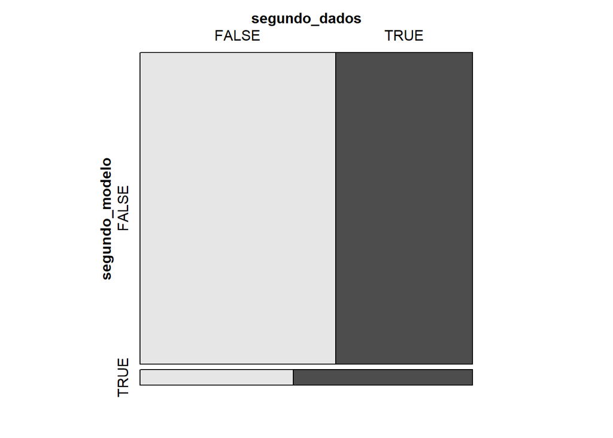

```r
mosaic(segundo_dados ~ segundo_modelo, data = previsoes,
       shade = T)
```